# Analyzing Individual BGG Users

Phil Henrickson

2021-12-04

Load previously queried training and test data from the local layer.

Set function for displaying probabilities

Fit models and analyze collection for **C3Gaming**.

## Games in Collection

How many games has the user owned/played in the training set (games prior to 2020)?

```
## # A tibble: 1 × 3
##   username games_owned games_played
##   <chr>          <dbl>        <dbl>
## 1 C3Gaming          62          118
```

## Coefficients for C3Gaming

Examine coefficients from the trained model.

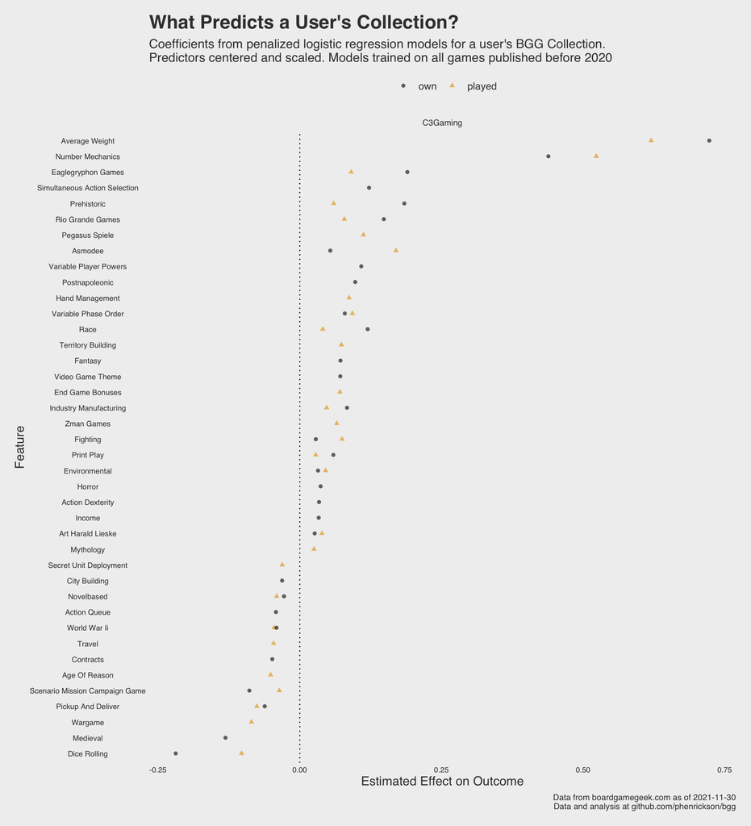

## Assessment

Examine separation plot for training set (cross validated predictions).

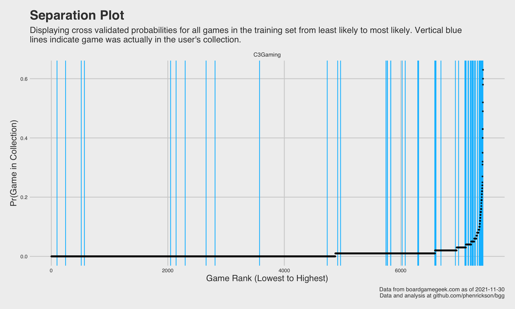

Formally assess how well the model did in resampling.

| outcome_type | .metric | .estimator | .estimate |
| --- | --- | --- | --- |
| own | roc_auc | binary | 0.838 |
| played | roc_auc | binary | 0.849 |

## Predicted Games in Collection from Training

Examine top games from resampling.

Top Overall Games for User from Resampling

| username | yearpublished | game_id | name | pred_played | pred_own | actual_played | actual_own |
| --- | --- | --- | --- | --- | --- | --- | --- |
| C3Gaming | 2015 | 175878 | 504 | 0.91 | 0.63 | 0 | 0 |
| C3Gaming | 2017 | 162886 | Spirit Island | 0.62 | 0.60 | 0 | 0 |
| C3Gaming | 2017 | 174430 | Gloomhaven | 0.87 | 0.58 | 1 | 0 |
| C3Gaming | 2010 | 62219 | Dominant Species | 0.76 | 0.52 | 1 | 1 |
| C3Gaming | 2007 | 28720 | Brass: Lancashire | 0.21 | 0.49 | 1 | 1 |
| C3Gaming | 2015 | 182028 | Through the Ages: A New Story of Civilization | 0.18 | 0.43 | 0 | 0 |
| C3Gaming | 2013 | 144239 | Impulse | 0.45 | 0.43 | 1 | 0 |
| C3Gaming | 2018 | 224517 | Brass: Birmingham | 0.26 | 0.40 | 0 | 0 |
| C3Gaming | 2018 | 205896 | Rising Sun | 0.82 | 0.35 | 1 | 1 |
| C3Gaming | 2017 | 233078 | Twilight Imperium: Fourth Edition | 0.52 | 0.32 | 0 | 0 |
| C3Gaming | 2017 | 221769 | Bios: Megafauna (Second Edition) | 0.12 | 0.31 | 1 | 1 |
| C3Gaming | 2013 | 141517 | A Study in Emerald | 0.06 | 0.27 | 0 | 0 |
| C3Gaming | 2010 | 77130 | Sid Meier's Civilization: The Board Game | 0.18 | 0.25 | 0 | 0 |
| C3Gaming | 2003 | 6707 | Age of Mythology: The Boardgame | 0.18 | 0.24 | 0 | 0 |
| C3Gaming | 2017 | 201186 | Summit: The Board Game | 0.23 | 0.24 | 0 | 0 |
| C3Gaming | 2019 | 267304 | Western Empires | 0.29 | 0.23 | 0 | 0 |
| C3Gaming | 2014 | 155703 | Evolution | 0.17 | 0.23 | 0 | 0 |
| C3Gaming | 2014 | 159675 | Fields of Arle | 0.20 | 0.22 | 0 | 0 |
| C3Gaming | 2018 | 247763 | Underwater Cities | 0.31 | 0.22 | 0 | 0 |
| C3Gaming | 2017 | 161533 | Lisboa | 0.23 | 0.22 | 1 | 1 |
| C3Gaming | 2016 | 182134 | Evolution: Climate | 0.10 | 0.22 | 0 | 0 |
| C3Gaming | 2019 | 251247 | Barrage | 0.62 | 0.21 | 0 | 0 |
| C3Gaming | 2016 | 167791 | Terraforming Mars | 0.41 | 0.21 | 1 | 0 |
| C3Gaming | 2018 | 313010 | Cosmic Encounter: 42nd Anniversary Edition | 0.14 | 0.20 | 0 | 0 |
| C3Gaming | 2019 | 235555 | Bios: Origins (Second Edition) | 0.14 | 0.19 | 1 | 1 |
| C3Gaming | 2016 | 98918 | Bios: Genesis | 0.06 | 0.19 | 1 | 1 |
| C3Gaming | 2017 | 221805 | Breaking Bad: The Board Game | 0.24 | 0.19 | 0 | 0 |
| C3Gaming | 2005 | 17133 | Railways of the World | 0.46 | 0.19 | 0 | 0 |
| C3Gaming | 2012 | 128780 | Pax Porfiriana | 0.07 | 0.19 | 0 | 0 |
| C3Gaming | 2002 | 3076 | Puerto Rico | 0.34 | 0.19 | 1 | 0 |

[output cut: 70 more lines]

### Most and Least Likely Games

What game does the model think C3Gaming is **most likely to own** that is **not** in their collection?

| username | yearpublished | game_id | name | pred_own |
| --- | --- | --- | --- | --- |
| C3Gaming | 2015 | 175878 | 504 | 0.63 |

What game does the model think C3Gaming is **least likely to own** that **is** in their collection?

| username | yearpublished | game_id | name | pred_own |
| --- | --- | --- | --- | --- |
| C3Gaming | 2003 | 7854 | YINSH | 0 |

### Top Games by Year

Top 25 games most likely to be owned by the user in each year, highlighting in blue the games that the user has owned/played.

| rank | 2012 | 2013 | 2014 | 2015 | 2016 | 2017 | 2018 | 2019 |
| --- | --- | --- | --- | --- | --- | --- | --- | --- |
| 1 | Pax Porfiriana | Impulse | Evolution | 504 | Evolution: Climate | Spirit Island | Brass: Birmingham | Western Empires |
| 2 | Exodus: Proxima Centauri | A Study in Emerald | Fields of Arle | Through the Ages: A New Story of Civilization | Terraforming Mars | Gloomhaven | Rising Sun | Barrage |
| 3 | The Great Zimbabwe | Patchistory | Power Grid Deluxe: Europe/North America | Blood Rage | Bios: Genesis | Twilight Imperium: Fourth Edition | Underwater Cities | Bios: Origins (Second Edition) |
| 4 | Fantastiqa: The Rucksack Edition | Triassic Terror | La Granja | Clockwork Wars | Vinhos Deluxe Edition | Bios: Megafauna (Second Edition) | Cosmic Encounter: 42nd Anniversary Edition | Maracaibo |
| 5 | Keyflower | Rococo | Three Kingdoms Redux | Food Chain Magnate | A Feast for Odin | Summit: The Board Game | New Frontiers | City of the Big Shoulders |
| 6 | War of the Ring: Second Edition | Race! Formula 90 | Smash Up: Science Fiction Double Feature | The Gallerist | Crazy Karts | Lisboa | Prehistory | Coloma |
| 7 | Space Cadets | Navajo Wars | Myth | The Bloody Inn | Heir to the Pharaoh | Breaking Bad: The Board Game | Root | Ecos: First Continent |
| 8 | Freedom: The Underground Railroad | Hegemonic | Tiny Epic Kingdoms | Trickerion: Legends of Illusion | Exceed Fighting System | Pendragon: The Fall of Roman Britain | Dead Man's Doubloons | Crusader Kings |
| 9 | Terra Mystica | City of Iron | Jäger und Späher | Tesla vs. Edison: War of Currents | Forged in Steel | Gaia Project | Renegade | Tapestry |
| 10 | Uchronia | A Distant Plain | Five Tribes | Mombasa | Codex: Card-Time Strategy – Core Set | LYNGK | Barbarians: The Invasion | Pangea |
| 11 | The Manhattan Project | 1862: Railway Mania in the Eastern Counties | Arkwright | Grimslingers | The Manhattan Project: Energy Empire | Rajas of the Ganges | Lords of Hellas | Jagged Alliance: The Board Game |
| 12 | Andean Abyss | Craftsmen | Kanban: Driver's Edition | Super Dungeon Explore: Forgotten King | Ave Roma | Too Many Bones | Street Masters | Era of Tribes |
| 13 | Myrmes | Colonialism | Shadows of Malice | The U.S. Civil War | Comanchería: The Rise and Fall of the Comanche Empire | The Ruhr: A Story of Coal Trade | The Manhattan Project 2: Minutes to Midnight | Cloudspire |
| 14 | Descent: Journeys in the Dark (Second Edition) | Tash-Kalar: Arena of Legends | Legendary Encounters: An Alien Deck Building Game | Copper Country | Agricola (Revised Edition) | Sword & Sorcery | Founders of Gloomhaven | Dune |
| 15 | Mage Wars Arena | Salmon Run | Roll for the Galaxy | Epic Card Game | Perdition's Mouth: Abyssal Rift | High Frontier (Third Edition) | Cerebria: The Inside World | Middara: Unintentional Malum – Act 1 |
| 16 | Divided Republic | Euphoria: Build a Better Dystopia | Castles of Mad King Ludwig | Neanderthal | Codex: Card-Time Strategy – Deluxe Set | Guards of Atlantis: Tabletop MOBA | Ground Floor (Second Edition) | Res Arcana |
| 17 | Polis: Fight for the Hegemony | Brew Crafters | The Lord of the Ice Garden | The King's Armory | Scythe | Lignum (Second Edition) | Newton | Living Planet |
| 18 | Tzolk'in: The Mayan Calendar | Kohle & Kolonie | Fire in the Lake | Empires: Age of Discovery | Falling Sky: The Gallic Revolt Against Caesar | Agra | CO₂: Second Chance | Pipeline |
| 19 | Might & Magic Heroes | Francis Drake | Alchemists | Wings for the Baron (Second Edition) | Liberty or Death: The American Insurrection | Escape from 100 Million B.C. | Pax Emancipation | Aeon's End: Legacy |
| 20 | Fleet | Dungeon Twister: The Card Game | Sons of Anarchy: Men of Mayhem | Argent: The Consortium | Star Wars: Rebellion | This War of Mine: The Board Game | Medioevo Universale | The Isle of Cats |
| 21 | Robinson Crusoe: Adventures on the Cursed Island | BioShock Infinite: The Siege of Columbia | Doomtown: Reloaded | Bright Future | Mistfall: Heart of the Mists | Colonial Twilight: The French-Algerian War, 1954-62 | The Pirate Republic | The Magnificent |
| 22 | Asgard | Rockwell | 18OE: On the Rails of the Orient Express | Kingdom Death: Monster | Mansions of Madness: Second Edition | Pericles: The Peloponnesian Wars | Nemesis | Pax Transhumanity |
| 23 | VivaJava: The Coffee Game | Origin | Praetor | Skull Tales | Bloodborne: The Card Game | Transatlantic | Too Many Bones: Undertow | Gandhi: The Decolonization of British India, 1917 – 1947 |
| 24 | Rex: Final Days of an Empire | Wildcatters | Pathfinder Adventure Card Game: Skull & Shackles – Base Set | DRCongo | Pandemic: Iberia | Dragonfire | Dungeon Alliance | The Hunters A.D. 2114 |
| 25 | Virgin Queen | Zpocalypse | Deus | Baseball Highlights: 2045 | Aeon's End | Here I Stand: 500th Anniversary Edition | TOKYO METRO | UBOOT: The Board Game |

### Interactive Table

Interactive table for predictions from resampling.

|  | username | yearpublished | rank | game_id | name | pred_played | pred_own | actual_played | actual_own |
| --- | --- | --- | --- | --- | --- | --- | --- | --- | --- |
| 1 | C3Gaming | 1900 | 848 | 188 | Go | 0.03 | 0.01 | 0 | 0 |
| 2 | C3Gaming | 1900 | 906 | 171 | Chess | 0.03 | 0.01 | 0 | 0 |
| 3 | C3Gaming | 1900 | 910 | 2065 | Shogi | 0.03 | 0.01 | 0 | 0 |
| 4 | C3Gaming | 1900 | 911 | 2393 | Xiangqi | 0.02 | 0.01 | 0 | 0 |
| 5 | C3Gaming | 1900 | 1544 | 2173 | 4 Player Chess | 0.02 | 0.01 | 0 | 0 |
| 6 | C3Gaming | 1900 | 1635 | 6817 | Schafkopf | 0.01 | 0.01 | 0 | 0 |
| 7 | C3Gaming | 1900 | 1638 | 21389 | Happy Families | 0.01 | 0.01 | 0 | 0 |
| 8 | C3Gaming | 1900 | 1643 | 38950 | Halma | 0.01 | 0.01 | 0 | 0 |
| 9 | C3Gaming | 1900 | 1879 | 6819 | Skat | 0.02 | 0.01 | 0 | 0 |
| 10 | C3Gaming | 1900 | 2101 | 2386 | Chinese Checkers | 0.01 | 0.01 | 0 | 0 |

[output cut: 7403 more lines]

## Predicted Games in Collection 2020 and On

Examine the top games for the test set.

Top Predicted Games for User, 2020 and On

| username | yearpublished | game_id | name | rank | own | played |
| --- | --- | --- | --- | --- | --- | --- |
| C3Gaming | 2020 | 184267 | On Mars | 1 | 0.73 | 0.94 |
| C3Gaming | 2020 | 284378 | Kanban EV | 2 | 0.31 | 0.28 |
| C3Gaming | 2020 | 291457 | Gloomhaven: Jaws of the Lion | 3 | 0.19 | 0.62 |
| C3Gaming | 2020 | 300322 | Hallertau | 4 | 0.17 | 0.28 |
| C3Gaming | 2020 | 281655 | High Frontier 4 All | 5 | 0.15 | 0.17 |
| C3Gaming | 2020 | 256317 | Guild Master | 6 | 0.14 | 0.40 |
| C3Gaming | 2020 | 246900 | Eclipse: Second Dawn for the Galaxy | 7 | 0.12 | 0.24 |
| C3Gaming | 2020 | 308765 | Praga Caput Regni | 8 | 0.08 | 0.23 |
| C3Gaming | 2020 | 306481 | Tawantinsuyu: The Inca Empire | 9 | 0.07 | 0.18 |
| C3Gaming | 2020 | 232414 | Oceans | 10 | 0.06 | 0.06 |
| C3Gaming | 2020 | 311193 | Anno 1800 | 11 | 0.06 | 0.07 |
| C3Gaming | 2020 | 310442 | Feierabend | 12 | 0.06 | 0.05 |
| C3Gaming | 2020 | 217990 | Stellar Horizons | 13 | 0.05 | 0.05 |
| C3Gaming | 2020 | 298572 | Cosmic Encounter Duel | 14 | 0.05 | 0.06 |
| C3Gaming | 2020 | 297030 | Tekhenu: Obelisk of the Sun | 15 | 0.05 | 0.09 |
| C3Gaming | 2020 | 259061 | Skytear | 16 | 0.05 | 0.07 |
| C3Gaming | 2020 | 300531 | Paleo | 17 | 0.05 | 0.05 |
| C3Gaming | 2020 | 318983 | Faiyum | 18 | 0.05 | 0.13 |
| C3Gaming | 2020 | 299317 | Aeon's End: Outcasts | 19 | 0.04 | 0.07 |
| C3Gaming | 2020 | 312804 | Pendulum | 20 | 0.04 | 0.05 |
| C3Gaming | 2020 | 305498 | Tomorrow Dies Today | 21 | 0.04 | 0.08 |
| C3Gaming | 2020 | 326767 | Infinity N4: Core Rules | 22 | 0.04 | 0.09 |
| C3Gaming | 2020 | 318472 | Blood Bowl: Second Season Edition | 23 | 0.04 | 0.09 |
| C3Gaming | 2020 | 285972 | HEXplore It: The Sands of Shurax | 24 | 0.04 | 0.08 |
| C3Gaming | 2020 | 298154 | Rolling Stock Stars | 25 | 0.03 | 0.05 |
| C3Gaming | 2020 | 299179 | Chancellorsville 1863 | 26 | 0.03 | 0.09 |
| C3Gaming | 2020 | 292187 | 1861/1867 Railways of Russia/Canada | 27 | 0.03 | 0.06 |
| C3Gaming | 2020 | 233673 | Exploration | 28 | 0.03 | 0.04 |
| C3Gaming | 2020 | 280794 | Etherfields | 29 | 0.03 | 0.05 |
| C3Gaming | 2020 | 296151 | Viscounts of the West Kingdom | 30 | 0.03 | 0.17 |

[output cut: 67 more lines]

Interactive table for 2020 and On

|  | username | yearpublished | game_id | name | rank | own | played |
| --- | --- | --- | --- | --- | --- | --- | --- |
| 1 | C3Gaming | 2020 | 184267 | On Mars | 1 | 0.73 | 0.94 |
| 2 | C3Gaming | 2021 | 310873 | Carnegie | 2 | 0.45 | 0.83 |
| 3 | C3Gaming | 2021 | 262941 | Dominant Species: Marine | 3 | 0.34 | 0.29 |
| 4 | C3Gaming | 2020 | 284378 | Kanban EV | 4 | 0.31 | 0.28 |
| 5 | C3Gaming | 2020 | 291457 | Gloomhaven: Jaws of the Lion | 5 | 0.19 | 0.62 |
| 6 | C3Gaming | 2022 | 281647 | Stellaris: Infinite Legacy | 6 | 0.19 | 0.17 |
| 7 | C3Gaming | 2020 | 300322 | Hallertau | 7 | 0.17 | 0.28 |
| 8 | C3Gaming | 2022 | 295770 | Frosthaven | 8 | 0.17 | 0.41 |
| 9 | C3Gaming | 2021 | 342942 | Ark Nova | 9 | 0.16 | 0.34 |
| 10 | C3Gaming | 2021 | 343905 | Boonlake | 10 | 0.16 | 0.38 |

[output cut: 1566 more lines]